# Unveiling Electoral Deception: An Investigation into Cheating Practices during Election 66

ขอขอบคุณข้อมูลจากกกตที่ดึงมาโดยชุมชน ก้าวgeek [download](https://docs.google.com/spreadsheets/d/1WE1yZ6TeyS0-40TWS8OupULc8I_JiWTAo5fm3OCozIo/edit#gid=1155138857)

แนวทางการวิเคราะห์ได้ไอเดียเริ่มต้นมาจากการวิคลิปบนยูทูบของช่อง[อาจารย์ ลอย ชุนพงษ์ทอง](https://www.youtube.com/@LoyAcademy)

> **disclaimer ยังไม่ได้ testโค้ดและทวนสอบข้อมูลอย่างถี่ถ้วน**

# 1 บทนำ

> อาจารย์ ลอย ชุนพงษ์ทอง (https://www.youtube.com/@LoyAcademy) ได้นำเสนอข้อมูลที่เป็นหลักฐานทางคณิตศาสตร์ที่ชี้ให้เห็นว่าการเปลี่ยนระบบเป็นกาบัตร 2 ใบ น่าจะมีส่วนอย่างมากทำให้มีพรรคการเมืองหน้าใหม่ทั้งหมด 6 พรรค ได้ ส.ส. ปัดเศษเข้าไปนั่งในสภา รวมไปถึงข้อมูลที่มีนัยยะทางคณิตศาสตร์ ว่าเขตที่ยิ่งมีการกาบัตรสลับใบมาก ยิ่งมีแน้วโน้มที่จะเกิดการทุจริการเลือกตั้งโดยการซื้อเสียงในเขตนั้นๆ หรือที่อาจารย์เรียกว่าทฤษฎีปลอกกระสุนปืน

> การทุจริตการเลือกตั้งโดยการซื้อเสียงมักจะทำโดยการซื้อเสียง ส.ส. เขตเนื่องจากใช้เงินลงทุนน้อยกว่ามากในการที่จะได้ 1 ที่นั่งและชาวบ้านที่ถูกซื้อเสียงเหล่านั้นก็มักจะกาบัตร 2 ใบเป็นเลขเดียวกันเพื่อป้องกันความผิดพลาดและง่ายต่อการจดจำ นี่จึงเป็นเหตุที่ระบบกาบัตร 2 ใบจึงได้ทิ้งร่องลอย หรือที่อาจารย์ลอยเรียกว่าปลอกกระสุนทิ้งไว้เกลื่อนตามทาง

> ในบทความนี้เราสามารถนำเสนอข้อมูลที่นำไปสู่ข้อบ่งชี้ ที่ทำให้เห็นว่าผู้สมัคร ส.ส.เขตใดหรือพรรคการเมืองใด มีแนวโน้มที่จะทุจริตอย่างมีนัยยะสำคัญ ในขณะเดียวกันเราก็สามารถวิเคราะห์ในเชิงตรงข้ามว่าผู้สมัคร ส.ส. เขตและพรรคการเมืองใดที่น่าจะใ ส.ส.ะอาด ไร้ซึ่งร่องรอยแห่งปลอกกระสุน ให้มีข้อต้องสงสัยใดๆเลย

# 2 ผลการเลือกตั้งคะแนนบัญชีรายชื่อ

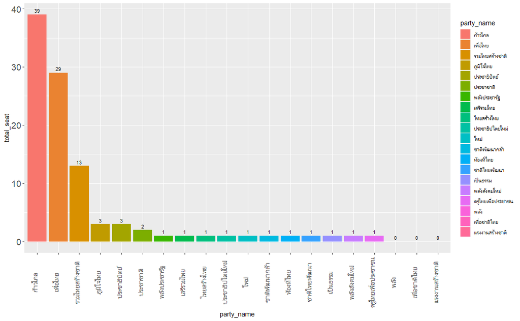

|  | เลขพรรค | พรรค | คะแนน | เปอร์เซ็นต์ | ที่นั่ง | เศษ | ที่นั่งปัดเศษ | รวมที่นั่ง |
| --- | --- | --- | --- | --- | --- | --- | --- | --- |
| 1 | 31 | ก้าวไกล | 14,233,895 | 38.47% | 38 | 0.47% | 1 | 39 |
| 2 | 29 | เพื่อไทย | 10,865,836 | 29.37% | 29 | 0.37% | 0 | 29 |
| 3 | 22 | รวมไทยสร้างชาติ | 4,673,691 | 12.63% | 12 | 0.63% | 1 | 13 |
| 4 | 7 | ภูมิใจไทย | 1,121,595 | 3.03% | 3 | 0.03% | 0 | 3 |
| 5 | 26 | ประชาธิปัตย์ | 899,303 | 2.43% | 2 | 0.43% | 1 | 3 |
| 6 | 11 | ประชาชาติ | 576,613 | 1.56% | 1 | 0.56% | 1 | 2 |
| 7 | 37 | พลังประชารัฐ | 530,017 | 1.43% | 1 | 0.43% | 0 | 1 |
| 8 | 25 | เสรีรวมไทย | 347,607 | 0.94% | 0 | 0.94% | 1 | 1 |
| 9 | 32 | ไทยสร้างไทย | 338,042 | 0.91% | 0 | 0.91% | 1 | 1 |
| 10 | 2 | ประชาธิปไตยใหม่ | 266,799 | 0.72% | 0 | 0.72% | 1 | 1 |

[output cut: 60 more lines]

> จากทั้งหมด 17 พรรคการเมืองที่ได้ทั้งนั่งบัญชีรายชื่ออย่างน้อย 1 ที่นั่ง จะสังเกตุได้ว่าพรรคเบอร์ 1 ถึง 6 ล้วนได้ที่นั่ง ส.ส.ปัดเศษกันทั้งสิ้น หากมองเลยไปถึงพรรคหมายเลข 8 และ 9 แม้จะไม่ได้ที่นั่ง แค่คะแนนบัญชีรายชื่อก็อยู่ใน 20 อันดับแรกสูงสุด

> ถามว่าทั้งหมดที่คือความบังเอิญหรือเป็นที่ข้อผิดพลาดของระบบเลือกตั้งบัตร 2 ใบกันแน่?

## 2.1 การกาสลับใบ

> หากสมมติฐานคือ พรรคเหล่านี้ได้อานิสงค์จากการกาสลับใบ คือการที่เอาเลข ส.ส.เขตไปกาคะแนนใบบัญชีรายชื่อก็ต้องถามต่อว่า ทำไมหวยถึงมาออกที่เพรรคหมายเลข 1-6? จริงๆแล้วพรรคอื่นๆก็ได้รับผลตรงนี้เช่นกันแต่พรรคเลขยิ่งน้อยยิ่งได้อนิสงส์มาก

> หากเราดูผู้สมัคร ส.ส. เขตทั่วประเทศจะพบว่ามีผู้ที่ได้รับหมายเลขสูงสุดคือหมายเลข 20 เป็นผู้สมัครจากพรรคคลองไทยในพื้นที่ขอนแก่นเขต 4

> แต่หากหากเราดูเฉพาะผู้สมัคร ส.ส. จาก 6 พรรคใหญ่พบหมายเลขสูงสุดคือหมายเลข 15 จำนวน 3 ท่าน ซึ่งเป็นผู้สมัครจากพรรคพลังประชารัฐและพรรคเพื่อไทยในจังหวัดกรุงเทพมหานคร

## 2.2 คะแนนเสียงของผู้สมัครแต่ละหมายเลขรวมกันทั้งประเทศ

| หมายเลขผู้สมัคร | จำนวนผู้สมัคร | คะแนนเสียง |
| --- | --- | --- |
| 1 | 400 | 4,028,809 |
| 2 | 400 | 3,945,151 |
| 3 | 400 | 3,863,685 |
| 4 | 400 | 4,154,464 |
| 5 | 400 | 4,146,458 |
| 6 | 400 | 3,958,313 |
| 7 | 400 | 3,736,529 |
| 8 | 400 | 3,130,961 |
| 9 | 383 | 2,814,870 |
| 10 | 349 | 1,171,399 |

[output cut: 10 more lines]

> จากข้อมูลชุดนี้จะพบว่า
> 1. ทั้ง 400 เขตมีผู้สมัครอย่างน้อย 8 คน
> 2. คะแนนเบอร์ 1-7 ไม่มีผลต่างอย่างมีนัยยนะสำคัญ
> 3. ตั้งแต่เบอร์ 10 ลงไป คะแนนเสียงที่ได้รับต่ำลงอย่างมีนัยยะสำคัญ

## 2.3 เสียงที่ได้มาโดยบังเอิญ

> เราพบว่าสำหรับพรรคเบอร์ 1-9 นั้น คะแนนบัญชีรายชื่อโดยเฉลี่ย 82.6% เป็นคะแนนที่ได้มาในเขตที่เลขของพรรคดันไปตรงกับผู้สมัคร ส.ส.จาก 6 พรรคใหญ่ และสูงถึงกว่า 87% สำหรับพรรคหมายเลข 3,5, และ 6

> หรือหากดูเป็นจำนวนเขตจะพบว่า 82.6% ของคะแนนเสียงพรรคเหล่านี้ได้มาจาก 59.8% ของจำนวนเขตทั้งหมด และคะแนนอีก 17.4% ได้มาจากเขต 40.2% ที่เหลือที่เลขพรรคไปตรงกับผู้สมัครจากพรรคอื่น

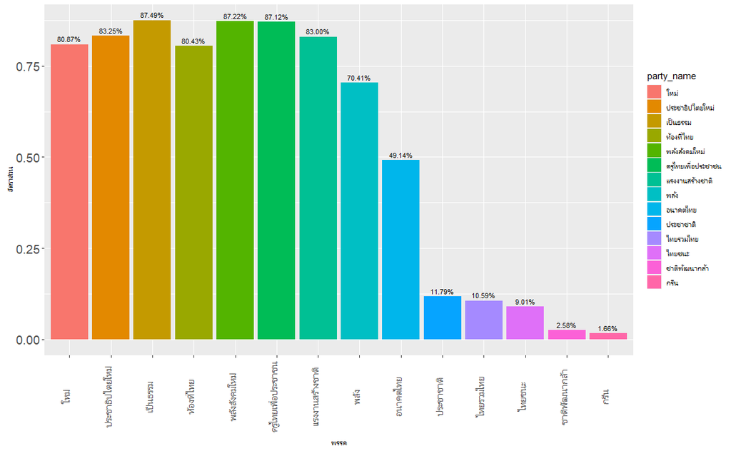

| หมายเลขพรรค | ชื่อพรรค | จำนวนเขตที่ตรง | คะแนนส้มหล่น | คะแนนทั้งหมด | อัตราส่วน |
| --- | --- | --- | --- | --- | --- |
| 1 | ใหม่ | 252 | 199,087 | 246,177 | 80.87% |
| 2 | ประชาธิปไตยใหม่ | 267 | 222,098 | 266,799 | 83.25% |
| 3 | เป็นธรรม | 252 | 158,964 | 181,699 | 87.49% |
| 4 | ท้องที่ไทย | 246 | 158,892 | 197,543 | 80.43% |
| 5 | พลังสังคมใหม่ | 267 | 152,550 | 174,897 | 87.22% |
| 6 | ครูไทยเพื่อประชาชน | 253 | 150,679 | 172,963 | 87.12% |
| 8 | แรงงานสร้างชาติ | 224 | 106,729 | 128,586 | 83.00% |
| 9 | พลัง | 151 | 108,848 | 154,602 | 70.41% |
| 10 | อนาคตไทย | 91 | 39,665 | 80,712 | 49.14% |
| 11 | ประชาชาติ | 55 | 67,990 | 576,613 | 11.79% |

[output cut: 4 more lines]

```
[1] 873678
[1] 848700
```

> เราพอจะสรุปได้ว่า
> 1. พรรคที่ได้อานิสงส์จากการที่หมายเลขตรงกับพรรคใหญ่คือพรรคหมายเลข 1-9
> 2. หมายเลข 10,11 ได้บ้างเพียงเล็กน้อย
> 3. ตั้งแต่ 12 ขึ้นไปแทบจะไม่ได้เลย

# 3 เป็นความบังเอิญจริงๆหรอ

> ที่นี้เรามาลองดูกันอีกมุมหนึ่งว่า พรรคเล็กเหล่านี้ได้คะแนนจากการที่เลขพรรคไปบังเอิญตรงกันกับ เลขผู้สมัคร ส.ส. ของพรรคใหญ่พรรคใหน

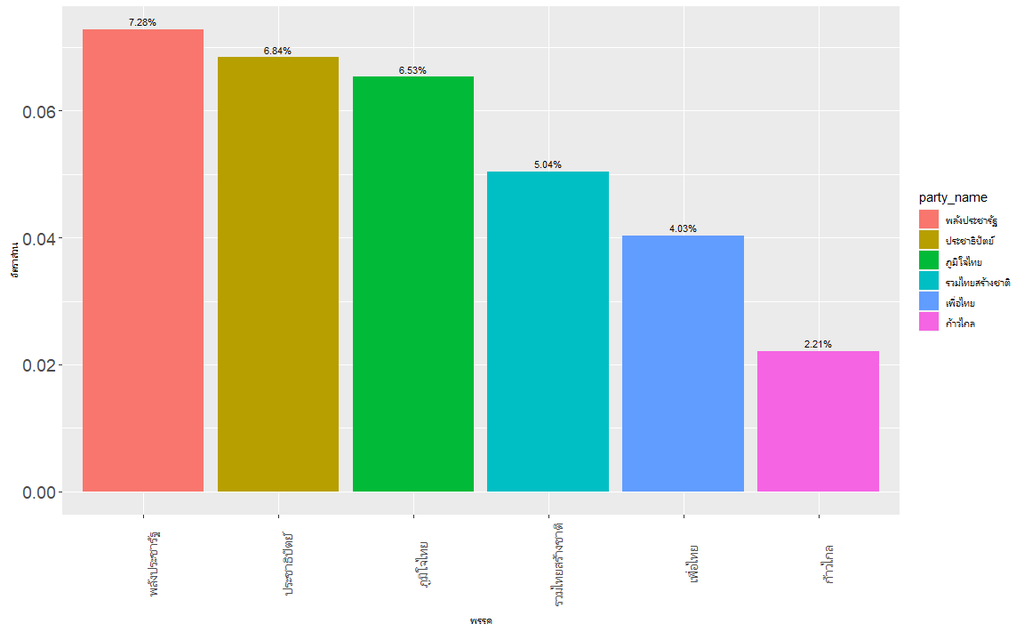

| ตรงกับพรรคใหญ่ | คะแนนเขตพรรคใหญ่ | คะแนนบัญชีรายชื่อพรรคเล็ก | จำนวนเขต | อัตราส่วน |
| --- | --- | --- | --- | --- |
| เพื่อไทย | 8,420,674 | 339,749 | 359 | 4.03% |
| ก้าวไกล | 8,260,753 | 182,687 | 342 | 2.21% |
| ภูมิใจไทย | 4,731,551 | 308,959 | 350 | 6.53% |
| พลังประชารัฐ | 3,617,346 | 263,218 | 354 | 7.28% |
| รวมไทยสร้างชาติ | 3,021,436 | 152,153 | 348 | 5.04% |
| ประชาธิปัตย์ | 1,989,999 | 136,095 | 346 | 6.84% |

> หากมันเป็นเพราะการกาสลับใบจริงๆ เหตุใดแฟนคลับก้าวไกลถึงกาสลับใบเพียงแค่ 2.21% แต่แฟนคลับพลังประชารัฐ ภูมิใจไทย และประชาธิปัตย์ถึงได้กาผิดกันถึง 6.5 - 7.2%

> แล้วถ้ามันไม่ใช่เป็นเพราะกาสลับใบ แต่เป็นเพราะพวกเขาเหล่านั้นตั้งใจกาเบอร์นี้ตั้งแต่แรก จะเป็นไปได้หรือไม่

# 4 ทฤษฎีปลอกกระสุน

> ดังที่ผมเขียนไว้ในบทนำว่า

> “การทุจริตการเลือกตั้งโดยการซื้อเสียงมักจะทำโดยการซื้อเสียง ส.ส. เขตเนื่องจากใช้เงินลงทุนน้อยกว่ามากในการที่จะได้ 1 ที่นั่งและชาวบ้านที่ถูกซื้อเสียงเหล่านั้นก็มักจะกาบัตร 2 ใบเป็นเลขเดียวกันเพื่อป้องกันความผิดพลาดและง่ายต่อการจดจำ”

> เมื่อใดก็ตามที่หมายเลขของ ส.ส. คนใดคนหนึ่งในพรรคใหญ่ไปตรงกับหมาบเลขพรรคของพรรคเล็ก คะแนนของพรรคเล็กเหล่านี้จะเป็นร่องรอย ที่เปรียบได้กับปลอกกระสุนดังที่อาจารย์ลอยได้ตั้งชื่อไว้(ชอบชื่อนี้มาก) แปลว่าเราสามารถมองหาปลอกกระสุนของ ส.ส. แต่ละคนได้ ถึงแม้ว่าเราจะไม่สามารถพิสูจน์ได้ว่าเขาเป็นคนยิงหรือไม่ก็ตาม ่ เราจะนิยามพรรคใหญ่คือ 6 พรรคที่ได้คะแนนบีญชีรายชื่อสูงที่สุด

> และพรรคเล็กคือ 8 พรรคเบอร์ 1 ถึง 9 ที่ไม่รวมภูมิใจไทย (หมายเลข 7)

## 4.1 ผู้ต้องสงสัย TOP 1%

> จากทั้งหมด 3200 เขต ( 8 พรรคเล็ก พรรคละ 400 เขต) เราลองมาเจาะลึกดูเฉพาะเขตที่พรรคเล็กได้คะแนนเสียงมากเป็นพิเศษ โดยจะเลือกมา 32 ตัวอย่างจาก 3200 (1% จาก 3200 ตัวอย่าง) โดยเรียงลำดับจากเขตที่พรรคเล็กได้คะแนนบัญชีรายชื่อได้มากที่สุด

> จากทั้งหมด 32 ตัวอย่าง หากเราเอาหมายเลขของพรรค มาหาว่าผู้สมัครท่านใดในเขตนั้นที่มีหมายเลขตรงกัน เราจะได้ผู้สมัครต้องสงสัยออกมาทั้งหมด 32 ท่านดังนี้

[output not shown]

[output cut: 22 more lines]

> เหลือเชื่อมั้ยครับว่าจากผู้สมัครต้องสงสัยทั้งหมด 32 ท่านนี้ที่เราเลือกมามีถึง 30 ท่านที่ชนะในเขตของตนเอง แถมอีก 2 ท่านที่เหลือก็ยังได้อันดับที่ 2

> หากกวาดตามองผ่านๆก็จะพบจุดสังเกตุว่าชื่อของพรรคภูมิใจไทยและพรรคพลังประชารัฐโผล่ขึ้นมาเต็มไปหมด

> หากผมทำตารางสรุปจากข้อมูลข้างต้นจะได้ออกมาดังนี้ครับ

|  | พรรค | จำนวนผู้สมัคร | จำนวนเขตที่ชนะ | คะแนนเขต | คะแนนบัญชีรายชื่อพรรคเล็ก | อัตราส่วน |
| --- | --- | --- | --- | --- | --- | --- |
| 1 | ภูมิใจไทย | 15 | 15 | 622,675 | 159,185 | 25.6% |
| 2 | พลังประชารัฐ | 9 | 9 | 360,322 | 31,739 | 8.8% |
| 3 | ประชาธิปัตย์ | 3 | 2 | 120,930 | 40,750 | 33.7% |
| 4 | เพื่อไทย | 2 | 1 | 57,668 | 75,479 | 130.9% |
| 5 | ชาติไทยพัฒนา | 2 | 2 | 98,516 | 34,407 | 34.9% |
| 6 | เพื่อไทรวมพลัง | 1 | 1 | 63,127 | 3,964 | 6.3% |

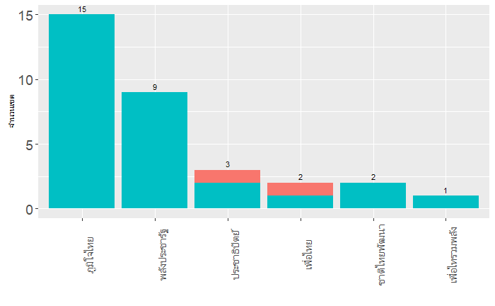

> เราพบผู้สมัครจากพรรคภูมิใจไทยถึง 15 ท่านและผู้สมัครจากพรรคพลังประชารัฐ 9 ท่าน แต่เรากลับไม่พบชื่อผู้สมัครจาก พรรคก้าวไกลเลยแม่แต่ท่านเดียว รวมถึงพรรครวมไทยสร้างชาติด้วย

> หากลองดูตัวเลขที่คอลัมน์สุดท้าย จะพบว่าในเขตเหล่านี้ สัดส่วนของคะแนนบัญชีรายชื่อเทียบกับคะแนน ส.ส.เขต ไม่สอดคล้องกันเลยโดยเฉพาะพลังประชารัฐที่ได้คะแนนบัญชีรายชื่อเพียง 8.8% เทียบกับคะแนน ส.ส. เขตทั้งๆที่หาก ตามสามัญสำนึกทั่วไปจะบอกเราว่า หากผู้ลงคะแนนคนใหนโหวตให้ ส.ส. ที่มาจากพรรคนั้นก็ควรจะลงคะแนนบัญชีรายชื่อให้พรรคนั้นๆ เช่นเดียวกัน แต่จากตัวเลขแล้วเราไม่เห็นเช่นนั้นเลยยกเว้นเพียงพรรคเดียวคือพรรคเพื่อไทยรรคเดียวคือพรรคเพื่อไทย

## 4.2 ผู้ต้องสงสัย TOP 3%

|  | พรรค | จำนวนผู้สมัคร | จำนวนเขตที่ชนะ | คะแนนเขต | คะแนนบัญชีรายชื่อพรรคเล็ก | อัตราส่วน |
| --- | --- | --- | --- | --- | --- | --- |
| 1 | ภูมิใจไทย | 41 | 33 | 1,586,357 | 329,717 | 20.785% |
| 2 | พลังประชารัฐ | 22 | 19 | 838,916 | 80,938 | 9.648% |
| 3 | เพื่อไทย | 16 | 14 | 690,874 | 630,527 | 91.265% |
| 4 | ประชาธิปัตย์ | 8 | 6 | 263,787 | 76,558 | 29.023% |
| 5 | รวมไทยสร้างชาติ | 4 | 3 | 144,858 | 70,834 | 48.899% |
| 6 | ชาติไทยพัฒนา | 3 | 3 | 138,231 | 38,127 | 27.582% |
| 7 | ชาติพัฒนากล้า | 1 | 0 | 31,768 | 8,735 | 27.496% |
| 8 | เพื่อไทรวมพลัง | 1 | 1 | 63,127 | 3,964 | 6.279% |

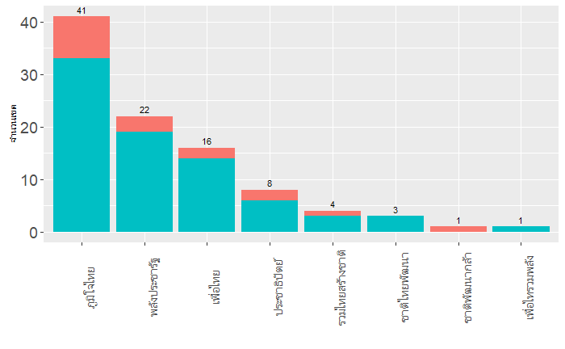

## 4.3 ผู้ต้องสงสัย TOP 5%

> เราลองหยิบตัวอย่างมาดูมากขึ้นอีกคือ Top 5% หรือ 160 ตัวอย่าง

|  | พรรค | จำนวนผู้สมัคร | จำนวนเขตที่ชนะ | คะแนนเขต | คะแนนบัญชีรายชื่อพรรคเล็ก | อัตราส่วน |
| --- | --- | --- | --- | --- | --- | --- |
| 1 | ภูมิใจไทย | 61 | 46 | 2,284,389 | 439,499 | 19.24% |
| 2 | พลังประชารัฐ | 37 | 26 | 1,281,258 | 129,307 | 10.09% |
| 3 | เพื่อไทย | 32 | 29 | 1,376,417 | 1,258,974 | 91.47% |
| 4 | ประชาธิปัตย์ | 10 | 6 | 312,178 | 89,375 | 28.63% |
| 5 | รวมไทยสร้างชาติ | 9 | 7 | 338,460 | 161,342 | 47.67% |
| 6 | ชาติไทยพัฒนา | 6 | 6 | 256,826 | 67,871 | 26.43% |
| 7 | ชาติพัฒนากล้า | 3 | 1 | 87,073 | 18,092 | 20.78% |
| 8 | ไทยสร้างไทย | 2 | 2 | 89,380 | 17,666 | 19.77% |
| 9 | เพื่อไทรวมพลัง | 1 | 1 | 63,127 | 3,964 | 6.28% |

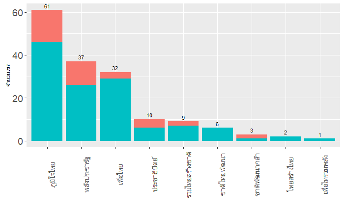

## 4.4 ข้อสรุปจากกลุ่มตัวอย่าง

> จาก 160 ตัวอย่างเรากลับไม่พบผู้ต้องสงสัยมาจากพรรคก้าวไกลเลยแม้แต่ท่านเดียว

> ทั้งๆที่พรรคก้าวไกลได้คะแนนรวมของ ส.ส. เขตมากที่สุดเป็นอันดับ 1 หากไม่มีการทุจริตใดๆเกิดขึ้นในการเลือกตั้งครั้งนี้ คะแนนที่จะถูกโยนไปให้บัญชีรายชื่อของพรรคเล็กเนื่องจากการกาสลับใบ ควรมาจากพรรคก้าวไกลมากที่สุด แต่ใน 160 ผู้ต้องสงสัยนี้ กลับไม่มีผู้สมัครพรรคก้าวไกลเลยแม้แต่ท่านเดียว ถึงแม้เราอาจจะไม่สามารถสรุปใด้แบบมั่นใจ 100% แต่มีความเป็นไปได้สูงมากที่ผู้สมัครทั้ง 160 ท่านนี้อาจจะเป็นเจ้าของปลอกกระสุนที่พวกเราเจอ

# 5 การคำนวนหาจำนวนกระสุนทั้งหมด

> หากเรานำผู้ต้องสงสัยทั้งหมด 3200 ผู้สมัคร แล้วคัดออกเหลือที่เป็นผู้สมัครพรรคใหญ่ 6 พรรค เราจะเหลือผู้ต้องสงสัยทั้งหมด 1,912 ท่าน โดยแบ่งออกเป็นผู้สมัครจากแต่ละพรรคได้ดังนี้

|  | พรรค | จำนวนผู้สมัคร |
| --- | --- | --- |
| 1 | ภูมิใจไทย | 320 |
| 2 | รวมไทยสร้างชาติ | 315 |
| 3 | ประชาธิปัตย์ | 315 |
| 4 | เพื่อไทย | 319 |
| 5 | ก้าวไกล | 316 |
| 6 | พลังประชารัฐ | 327 |

> หากเราเอาผู้สมัครแต่ละพรรคมาจัดอันดับภายในพรรคตั้งแต่อันดับ 1 จนถึงอันดับสุดท้าย เรียงตามลำดับความน่าสงสัย (คะแนนบัญชีรายชื่อของพรรคเล็ก) จากนั้นคำนวนจำนวนที่นั่งสะสมที่พรรคนั้นๆได้มา จะได้กราฟหน้าตาออกมาแบบนี้

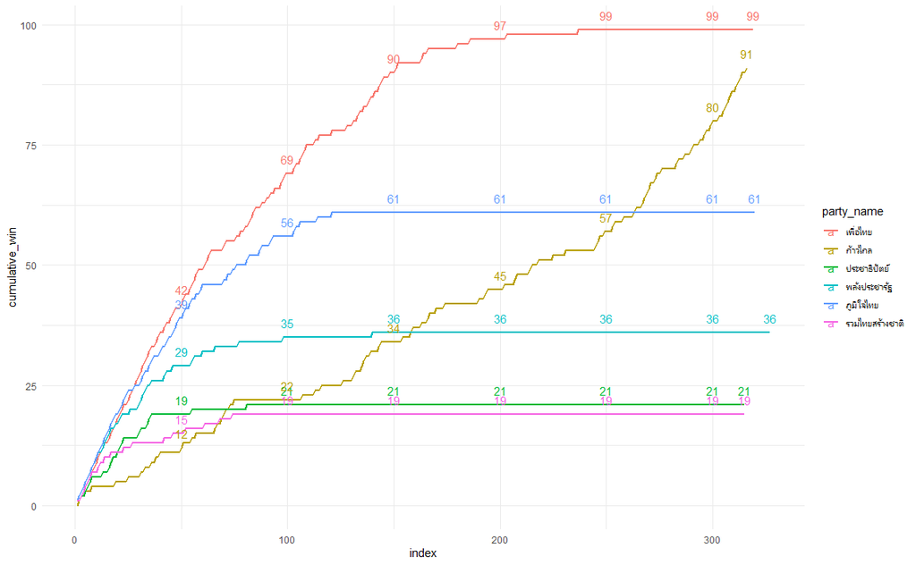

## 5.1 ข้อสังเกตุ

> ก้าวไกลเป็นพรรคเดียวที่ไม่พบความสัมพันธ์ระหว่างคะแนนบัญชีรายชื่อพรรคเล็ก และโอกาสชนะของ ส.ส. เขต ส่วนพรรคอื่นๆล้วนแล้วแต่ได้ ส.ส. ส่วนใหญ่ในเขตที่พรรคเล็กได้คะแนนบัญชีรายชื่อมากกันทั้งสิ้น

## 5.2 เราจะทำการคัทออฟตัดเขตต้องสงสัยต่ำออกไปได้คร่าวๆดังนี้

|  | พรรค | ลำดับผู้ต้องสงสัยคนสุดท้าย |
| --- | --- | --- |
| 1 | ภูมิใจไทย | 121 |
| 2 | รวมไทยสร้างชาติ | 76 |
| 3 | ประชาธิปัตย์ | 56 |
| 4 | เพื่อไทย | 180 |
| 5 | ก้าวไกล | 0 |
| 6 | พลังประชารัฐ | 77 |

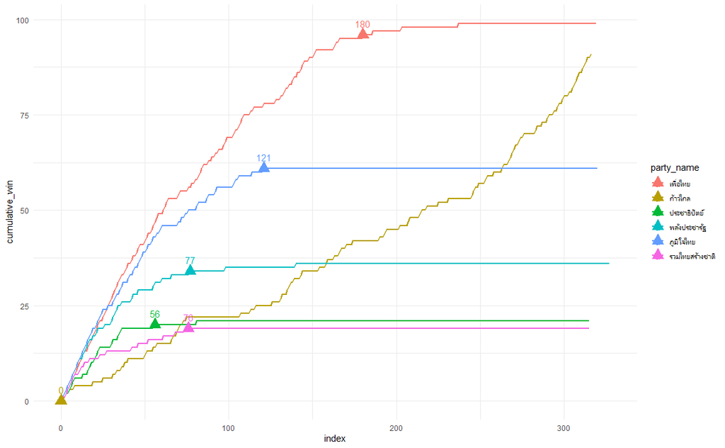

## 5.3 การคำนวนด้วยจำนวนปลอกกระสุน

> เราสามารถคาดประมานการจำนวนคะแนนที่ถูกซื้อเสียง โดยคำนวนจากคะแนนของพรรคเล็กที่มีหมายเลขพรรคตรงกับผู้สมัครในเขตนั้นๆทั้งหมด

|  | พรรค | คะแนนซื้อเสียง | จำนวนเขต |
| --- | --- | --- | --- |
| 1 | เพื่อไทย | 262,099 | 180 |
| 2 | ภูมิใจไทย | 240,312 | 121 |
| 3 | พลังประชารัฐ | 156,328 | 77 |
| 4 | รวมไทยสร้างชาติ | 84,467 | 76 |
| 5 | ประชาธิปัตย์ | 75,541 | 56 |

```
รวมทั้งหมด 818747  เสียง
```

## 5.4 การคำนวนด้วยการเทียบบัญญติยางค์

[output not shown]

```
รวมทั้งหมด 848700 เสียง
```

> ซึ่งทั้ง 2 วิธีต่างก็ออกมาได้ตัวเลขใกลเคียงกัน

# 6 บทสรุป

> คาดการณ์ว่ามีการสาดกระสุนมากกว่า 8 แสนนัดและอาจจะไปถึง 1 ล้านนัดทั่วประเทศ ตีมูลค่าได้นับพันล้านบาท

> อย่างไรก็ตามเราไม่สามารถสรุปตัวเลขได้แน่ชัด เป็นเพียงแค่การคาดการณ์ทางคณิตศาสตร์เท่านั้น อีกทั้งก็ไม่สามารถสรุปได้ว่าพรรคก้าวไกลไม่มีการซื้อเสียง เพียงแต่ว่าเรายังไม่พบกระสุนเท่านั้นเอง

> **การวิเคราะห์ทั้งหมดนี้ ยังไม่ได้มีการทวนสอบโค้ดและตัวเลขอย่างถี่ถ้วน**